# Chapter 9 - ARIMA Models Forecasting: Principles and Practice

R. J. Serrano

05/12/2023

# ARIMA models —

Learning objectives:

- Stationarity and differencing
- Non-seasonal ARIMA models
- Estimation and order selection
- ARIMA modeling in R
- Forecasting
- Seasonal ARIMA models
- ARIMA vs ETS

# Introduction —

ARIMA models provide another approach to time series forecasting. While exponential smoothing models are based on a description of the trend and seasonality in the data, ARIMA models aim to describe the autocorrelations in the data.

# 9.1 - Stationarity and differencing —

A stationary time series is one whose statistical properties do not depend on the time at which the series is observed.

Thus, a stationary time series exhibits the following characteristics:

- Roughly horizontal (no trend)
- Constant variance
- No long-term predictable patterns

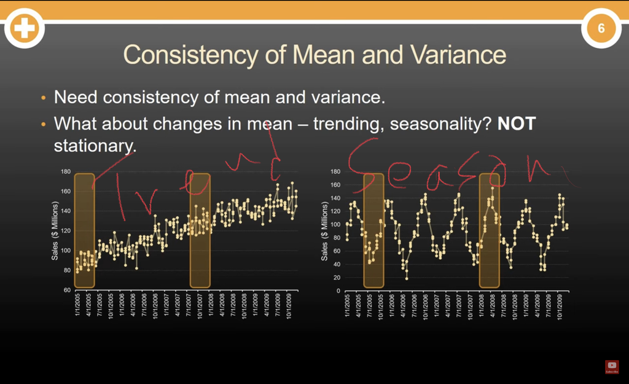

Source: What is stationarity? https://youtu.be/aIdTGKjQWjA

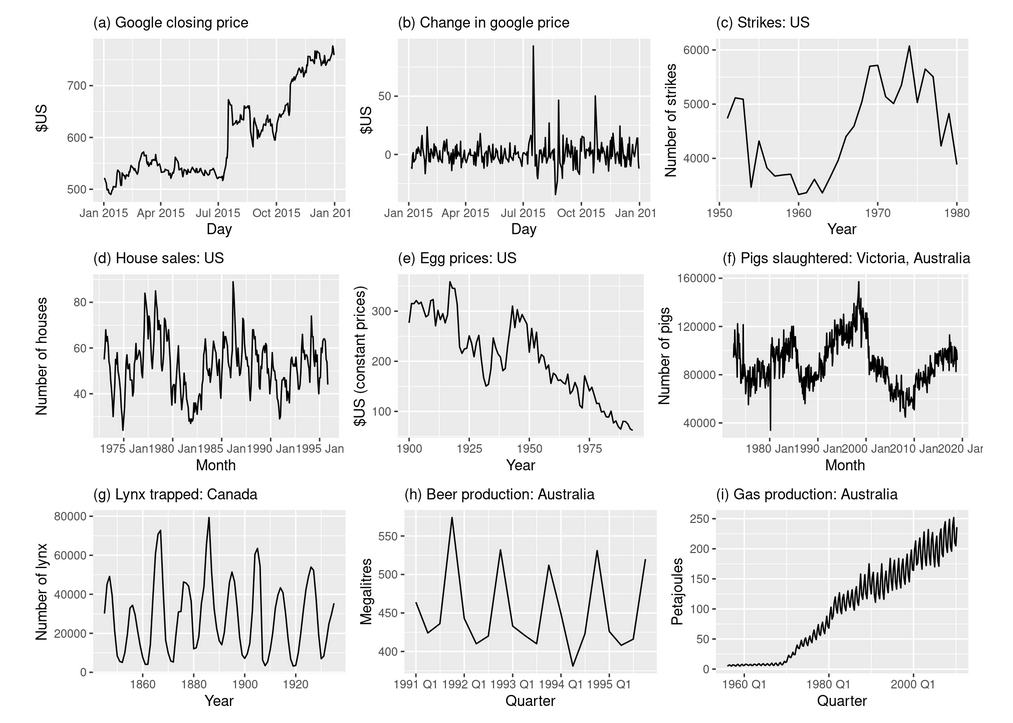

Figure 9.1: Which of this series are stationary?

# Differencing

In Figure 9.1, note that the Google stock price was non-stationary in panel (a), but the daily changes were stationary in panel (b). This shows one way to make a non-stationary time series stationary — compute the differences between consecutive observations. This is known as **differencing**.

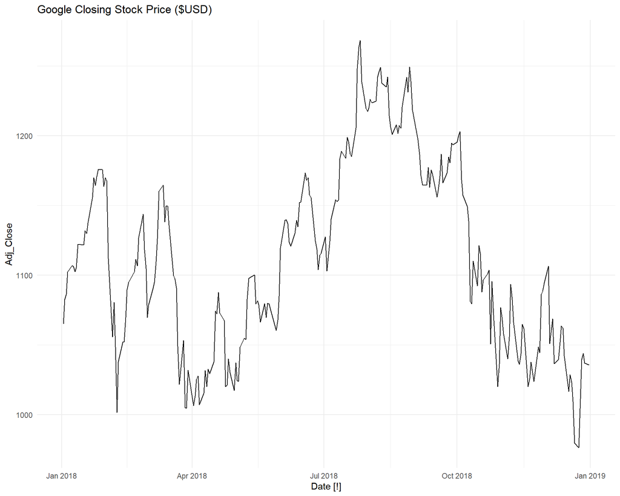

```r
google_2018 <- gafa_stock |>
  filter(Symbol == "GOOG", year(Date) == 2018)

# original time series
google_2018 |>
     autoplot(Adj_Close) +
     labs(title = 'Google Closing Stock Price ($USD)')
```

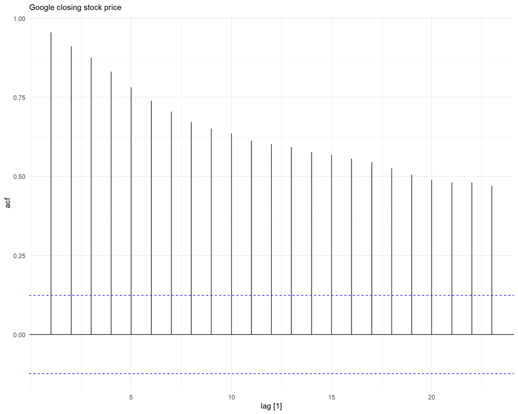

```r
google_2018 |> ACF(Close) |>
  autoplot() + labs(subtitle = "Google closing stock price")
```

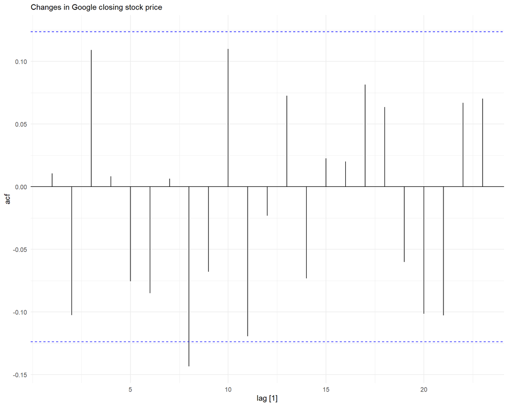

```r
google_2018 |> ACF(difference(Close)) |>
  autoplot() + labs(subtitle = "Changes in Google closing stock price")
```

```r
google_2018 |>
  mutate(diff_close = difference(Close)) |>
  features(diff_close, ljung_box, lag = 8)
```

| Symbol | lb_stat | lb_pvalue |
| --- | --- | --- |
| GOOG | 14.45101 | 0.07074136 |

The ACF of the differenced Google stock price looks just like that of a white noise series. Since the p-value is greater than 0.05, this suggests that the *daily change* in the Google stock price is essentially a random amount which is uncorrelated with that of previous days.

# Random walk model —-

A time series is said to follow a random walk process if the predicted value of the series in one period is equivalent to the value of the series in the previous period plus a random error. Source: https://analystprep.com/study-notes/cfa-level-2/random-walk-process/

Random walk models are widely used for non-stationary data, particularly financial and economic data. Random walks typically have:

- long periods of apparent trends up or down
- sudden and unpredictable changes in direction

# Seasonal differening —-

A seasonal difference is the difference between an observation and the corresponding observation from the previous year.
$$y'_t = y_t - y_{t-m}$$
Antidiabetic drug sales

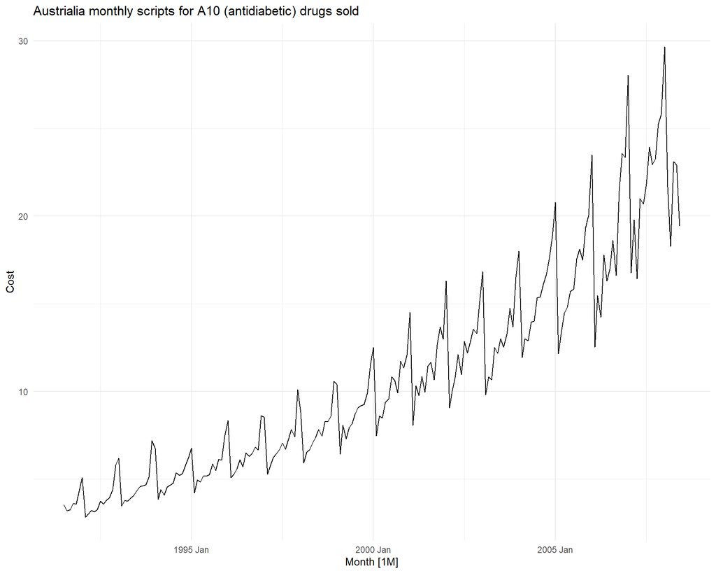

```r
a10 <- PBS |>
  filter(ATC2 == "A10") |>
  summarise(Cost = sum(Cost) / 1e6)

a10 |> autoplot(
  Cost
) +
     labs(title = 'Austrialia monthly scripts for A10 (antidiabetic) drugs sold')
```

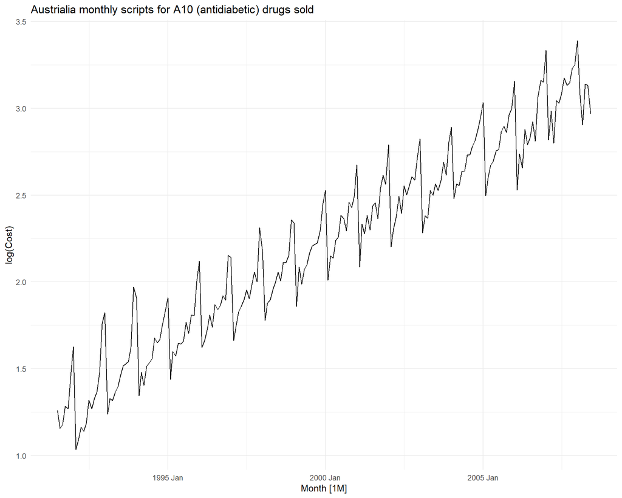

```r
a10 |> autoplot(
  log(Cost)
) +
     labs(title = 'Austrialia monthly scripts for A10 (antidiabetic) drugs sold')
```

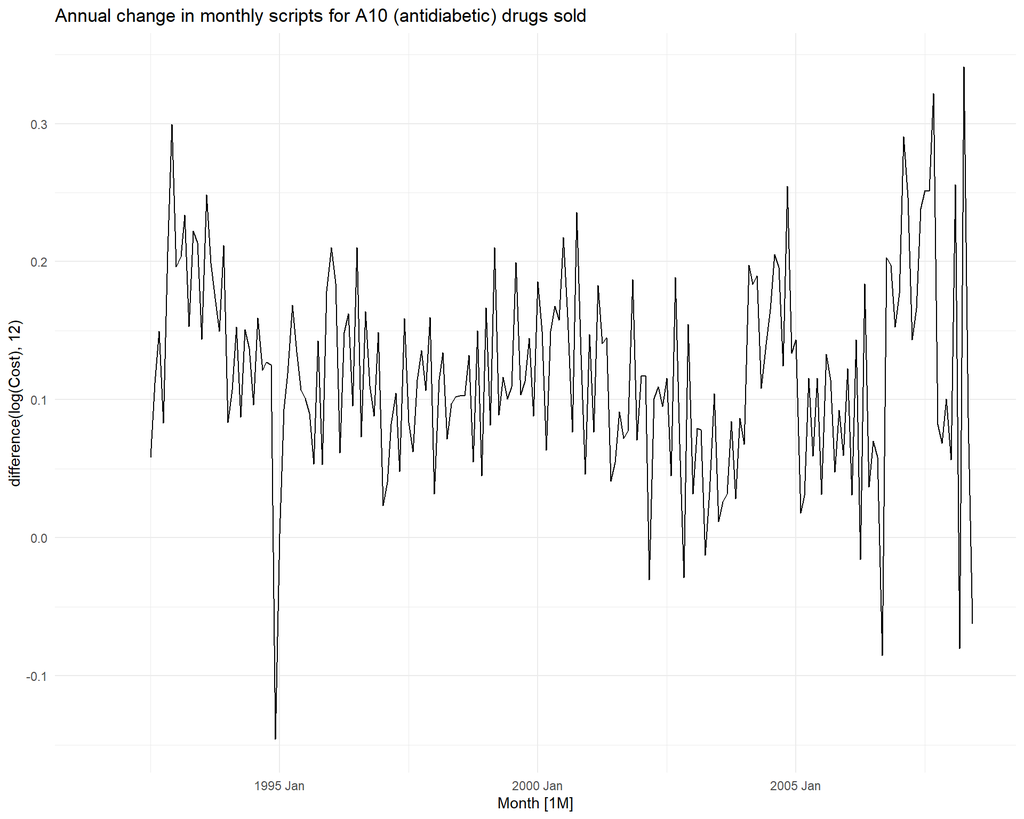

```r
a10 |> autoplot(
  log(Cost) |> difference(12)
) +
     labs(title = 'Annual change in monthly scripts for A10 (antidiabetic) drugs sold')
```

# Unit root test —-

One way to determine more objectively whether differencing is required is to use a *unit root test*. These are statistical hypothesis tests of stationarity that are designed for determining whether differencing is required.

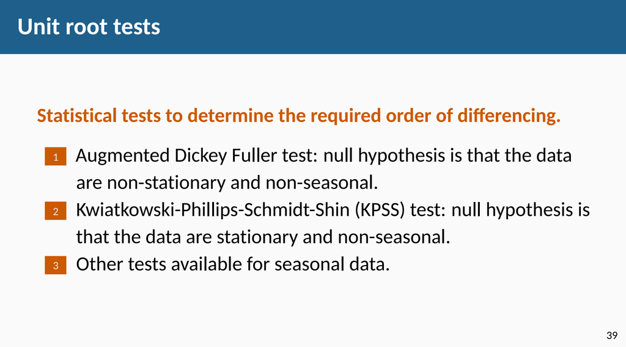

Source: textbook Chapter 9.1

For example, let us apply it to the Google stock price data.

```r
google_2018 |>
  features(Close, unitroot_kpss)
```

| Symbol | kpss_stat | kpss_pvalue |
| --- | --- | --- |
| GOOG | 0.5730076 | 0.02522351 |

The p-value is less than 0.05, so the null hypothesis (time series is stationary) is rejected in favor of the alternate hypothesis (time series is **NOT** stationary).

We can difference the time series and apply the test again.

```r
google_2018 |>
  mutate(diff_close = difference(Close)) |>
  features(diff_close, unitroot_kpss)
```

| Symbol | kpss_stat | kpss_pvalue |
| --- | --- | --- |
| GOOG | 0.09551033 | 0.1 |

This time, the p-value is greater than 0.05, so we can conclude that the time series appears stationary.

# 9.2 - Backshift notation

A very useful notational device is the backward shift operator, $B$, which is used as follows:
$$B y_{t} = y_{t - 1}$$

In other words, $B$, operating on $y_{t}$, has the effect of **shifting the data back one period**.

Two applications of $B$ to $y_{t}$ **shifts the data back two periods**:
$$B(By_{t}) = B^{2}y_{t} = y_{t-2}$$

# 9.3 - Autoregressive models

In a multiple regression model, introduced in Chapter 7, we forecast the variable of interest using a linear combination of predictors. In an autoregression model, we forecast the variable of interest using a linear combination of *past values of the variable*. The term *auto*regression indicates that it is a regression of the variable **against itself**.

## AR(1) model

- When $\phi_1=0$, $y_t$ is **equivalent to WN**
- When $\phi_1=1$ and $c=0$, $y_t$ is **equivalent to a RW**
- When $\phi_1=1$ and $c\ne0$, $y_t$ is **equivalent to a RW with drift**
- When $\phi_1<0$, $y_t$ tends to **oscillate between positive and negative values**.

# 9.4 - Moving average models

## Invertibility

- Any MA($q$) process can be written as an AR($\infty$) process if we impose some constraints on the MA parameters.
- Then the MA model is called “invertible”.
- Invertible models have some mathematical properties that make them easier to use in practice.
- Invertibility of an ARIMA model is equivalent to forecastability of an ETS model.

# 9.5 - Non-seasonal ARIMA models

If we combine differencing with autoregression and a moving average model, we obtain a non-seasonal ARIMA model. ARIMA is an acronym for AutoRegressive Integrated Moving Average (in this context, “integration” is the reverse of differencing).

The full model can be written as :